# Data Mining Principles - Final Project - Fraud Detection

Luke Schwenke, Soheb Osmani, Ken Ma

2023-03-08

The following R Markdown covers different data mining applications in an effort to predict vehicle insurance fraud for a car insurance provider. We used the following techniques:

**Supervised Models Used:** GLM, GLM with Stepwise Regression, Classification Tree, SVM, Naive Bayes **Unsupervised Algorithm Used**: t-SNE

A final ensemble model was used to combine the supervised models to form a majority-vote fraud/not-fraud prediction

```r
# Load necessary packages
library(tidyverse)
library(MASS)
library(MLmetrics)
library(caret)
library(rpart)
library(rpart.plot)
library(mclust)
library(Rtsne)
library(ggplot2)
library(e1071)
library(naivebayes)
library(randomForest)
library(pROC)
library(PRROC)

set.seed(777)

# Load insurance fraud dataset, setting strings to factors
insurance_fraud <- read.csv("fraud.csv", stringsAsFactors = TRUE)

# Drop columns that do not provide value
insurance_fraud <- insurance_fraud %>% dplyr::select(-PolicyNumber, -RepNumber, -Age)

# Print the first 10 lines of dataset
head(insurance_fraud, n = 10)
```

```
##    Month WeekOfMonth DayOfWeek   Make AccidentArea DayOfWeekClaimed
## 1    Dec           5 Wednesday  Honda        Urban          Tuesday
## 2    Jan           3 Wednesday  Honda        Urban           Monday
## 3    Oct           5    Friday  Honda        Urban         Thursday
## 4    Jun           2  Saturday Toyota        Rural           Friday
## 5    Jan           5    Monday  Honda        Urban          Tuesday
## 6    Oct           4    Friday  Honda        Urban        Wednesday
## 7    Feb           1  Saturday  Honda        Urban           Monday
## 8    Nov           1    Friday  Honda        Urban          Tuesday
## 9    Dec           4  Saturday  Honda        Urban        Wednesday
## 10   Apr           3   Tuesday   Ford        Urban        Wednesday
##    MonthClaimed WeekOfMonthClaimed    Sex MaritalStatus         Fault
## 1           Jan                  1 Female        Single Policy Holder
## 2           Jan                  4   Male        Single Policy Holder
## 3           Nov                  2   Male       Married Policy Holder
```

[output cut: 51 more lines]

```r
c(names(insurance_fraud))
```

```
##  [1] "Month"                "WeekOfMonth"          "DayOfWeek"
##  [4] "Make"                 "AccidentArea"         "DayOfWeekClaimed"
##  [7] "MonthClaimed"         "WeekOfMonthClaimed"   "Sex"
## [10] "MaritalStatus"        "Fault"                "PolicyType"
## [13] "VehicleCategory"      "VehiclePrice"         "FraudFound_P"
## [16] "Deductible"           "DriverRating"         "Days_Policy_Accident"
## [19] "Days_Policy_Claim"    "PastNumberOfClaims"   "AgeOfVehicle"
## [22] "AgeOfPolicyHolder"    "PoliceReportFiled"    "WitnessPresent"
## [25] "AgentType"            "NumberOfSuppliments"  "AddressChange_Claim"
## [28] "NumberOfCars"         "Year"                 "BasePolicy"
```

# **Examine Dataset**

```r
# Examine structure of dataset
str(insurance_fraud)
```

```
## 'data.frame':    15420 obs. of  30 variables:
##  $ Month               : Factor w/ 12 levels "Apr","Aug","Dec",..: 3 5 11 7 5 11 4 10 3 1 ...
##  $ WeekOfMonth         : int  5 3 5 2 5 4 1 1 4 3 ...
##  $ DayOfWeek           : Factor w/ 7 levels "Friday","Monday",..: 7 7 1 3 2 1 3 1 3 6 ...
##  $ Make                : Factor w/ 19 levels "Accura","BMW",..: 7 7 7 18 7 7 7 7 7 6 ...
##  $ AccidentArea        : Factor w/ 2 levels "Rural","Urban": 2 2 2 1 2 2 2 2 2 2 ...
##  $ DayOfWeekClaimed    : Factor w/ 8 levels "0","Friday","Monday",..: 7 3 6 2 7 8 3 7 8 8 ...
##  $ MonthClaimed        : Factor w/ 13 levels "0","Apr","Aug",..: 6 6 11 7 5 11 5 9 4 2 ...
##  $ WeekOfMonthClaimed  : int  1 4 2 1 2 1 3 4 5 3 ...
##  $ Sex                 : Factor w/ 2 levels "Female","Male": 1 2 2 2 1 2 2 2 2 2 ...
##  $ MaritalStatus       : Factor w/ 4 levels "Divorced","Married",..: 3 3 2 2 3 3 2 3 3 2 ...
##  $ Fault               : Factor w/ 2 levels "Policy Holder",..: 1 1 1 2 2 2 2 1 1 1 ...
##  $ PolicyType          : Factor w/ 9 levels "Sedan - All Perils",..: 6 5 5 3 5 5 5 5 5 7 ...
##  $ VehicleCategory     : Factor w/ 3 levels "Sedan","Sport",..: 2 2 2 2 2 2 2 2 2 3 ...
##  $ VehiclePrice        : Factor w/ 6 levels "20000 to 29000",..: 6 6 6 1 6 6 6 6 6 6 ...
```

[output cut: 16 more lines]

```r
# Check dimensions of dataset
dim(insurance_fraud)
```

```
## [1] 15420    30
```

```r
# Check data types of variables
sapply(insurance_fraud, class)
```

```
##                Month          WeekOfMonth            DayOfWeek
##             "factor"            "integer"             "factor"
##                 Make         AccidentArea     DayOfWeekClaimed
##             "factor"             "factor"             "factor"
##         MonthClaimed   WeekOfMonthClaimed                  Sex
##             "factor"            "integer"             "factor"
##        MaritalStatus                Fault           PolicyType
##             "factor"             "factor"             "factor"
##      VehicleCategory         VehiclePrice         FraudFound_P
##             "factor"             "factor"            "integer"
##           Deductible         DriverRating Days_Policy_Accident
##            "integer"            "integer"             "factor"
##    Days_Policy_Claim   PastNumberOfClaims         AgeOfVehicle
##             "factor"             "factor"             "factor"
##    AgeOfPolicyHolder    PoliceReportFiled       WitnessPresent
##             "factor"             "factor"             "factor"
##            AgentType  NumberOfSuppliments  AddressChange_Claim
##             "factor"             "factor"             "factor"
##         NumberOfCars                 Year           BasePolicy
##             "factor"            "integer"             "factor"
```

```r
# Identify missing values and count them
sapply(insurance_fraud, function(x) sum(is.na(x)))
```

```
##                Month          WeekOfMonth            DayOfWeek
##                    0                    0                    0
##                 Make         AccidentArea     DayOfWeekClaimed
##                    0                    0                    0
##         MonthClaimed   WeekOfMonthClaimed                  Sex
##                    0                    0                    0
##        MaritalStatus                Fault           PolicyType
##                    0                    0                    0
##      VehicleCategory         VehiclePrice         FraudFound_P
##                    0                    0                    0
##           Deductible         DriverRating Days_Policy_Accident
##                    0                    0                    0
##    Days_Policy_Claim   PastNumberOfClaims         AgeOfVehicle
##                    0                    0                    0
##    AgeOfPolicyHolder    PoliceReportFiled       WitnessPresent
##                    0                    0                    0
##            AgentType  NumberOfSuppliments  AddressChange_Claim
##                    0                    0                    0
##         NumberOfCars                 Year           BasePolicy
##                    0                    0                    0
```

```r
# Use mutate_if() to address outliers in only numeric columns
#insurance_fraud <- insurance_fraud %>% mutate_if(is.numeric, funs(replace(., . > quantile(., 0.75) + 1.5*IQR(.) | . < quantile(., 0.25) - 1.5*IQR(.), NA)))

# Create copy
df <- insurance_fraud
table(df$FraudFound_P)
```

```
##
##     0     1
## 14497   923
```

```r
# Remove problems row with 0 as MonthClaim and DayOfWeekClaimed and PolicyType of Sport
df <- df %>% filter(DayOfWeekClaimed!=0 & MonthClaimed!=0)
df <- df %>% filter(PolicyType!="Sport - Liability")
```

# **Train-Test-Split**

```r
df$id <- 1:nrow(df)
train <- df %>% dplyr::sample_frac(0.8)
test <- dplyr::anti_join(df, train, by = 'id')
train$id <- NULL
test$id <- NULL

# Set dependent variable to factor
train$FraudFound_P <- as.factor(train$FraudFound_P)
test$FraudFound_P <- as.factor(test$FraudFound_P)

# Create Confusion Matrix Drawer Function
draw_confusion_matrix <- function(cm) {

  layout(matrix(c(1,1,2)))
  par(mar=c(2,2,2,2))
  plot(c(100, 345), c(300, 450), type = "n", xlab="", ylab="", xaxt='n', yaxt='n')
  title('CONFUSION MATRIX', cex.main=2)

  # create the matrix
  rect(150, 430, 240, 370, col='#3F97D0')
  text(195, 435, '0 - Not Fraud', cex=1.2)
  rect(250, 430, 340, 370, col='#F7AD50')
  text(295, 435, '1 - Fraud', cex=1.2)
  text(125, 370, 'Predicted', cex=1.3, srt=90, font=2)
  text(245, 450, 'Actual', cex=1.3, font=2)
  rect(150, 305, 240, 365, col='#F7AD50')
  rect(250, 305, 340, 365, col='#3F97D0')
  text(140, 400, '0 - Not Fraud', cex=1.2, srt=90)
  text(140, 335, '1 - Fraud', cex=1.2, srt=90)

  # add in the cm results
  res <- as.numeric(cm$table)
  text(195, 400, res[1], cex=1.6, font=2, col='white')
  text(195, 335, res[2], cex=1.6, font=2, col='white')
  text(295, 400, res[3], cex=1.6, font=2, col='white')
  text(295, 335, res[4], cex=1.6, font=2, col='white')

  # add in the specifics
  plot(c(100, 0), c(100, 0), type = "n", xlab="", ylab="", main = "DETAILS", xaxt='n', yaxt='n')
  text(10, 85, names(cm$byClass[11]), cex=1.2, font=2)
  text(10, 70, round(as.numeric(cm$byClass[11]), 3), cex=1.2)
  text(30, 85, names(cm$byClass[2]), cex=1.2, font=2)
  text(30, 70, round(as.numeric(cm$byClass[2]), 3), cex=1.2)
  text(50, 85, names(cm$byClass[5]), cex=1.2, font=2)
  text(50, 70, round(as.numeric(cm$byClass[5]), 3), cex=1.2)
  text(70, 85, names(cm$byClass[6]), cex=1.2, font=2)
  text(70, 70, round(as.numeric(cm$byClass[6]), 3), cex=1.2)
  text(90, 85, names(cm$byClass[7]), cex=1.2, font=2)
  text(90, 70, round(as.numeric(cm$byClass[7]), 3), cex=1.2)

  # add in the accuracy information
  text(30, 35, names(cm$overall[1]), cex=1.5, font=2)
  text(30, 20, round(as.numeric(cm$overall[1]), 3), cex=1.4)
  text(70, 35, names(cm$overall[2]), cex=1.5, font=2)
  text(70, 20, round(as.numeric(cm$overall[2]), 3), cex=1.4)
}
```

# **Construct base GLM Model with All Variables**

```r
set.seed(777)

# Set threshold for what is fraud (1) and not fraud (0)
thresh = 0.5

############# Baseline Logistic Regression on ALL variables #############

# Construct baseline model and print the summary
base_log_reg <- glm(FraudFound_P ~ ., data=train ,family = binomial(link = "logit"))

# Get the fitted values (predictions) on the train set
base_vals = base_log_reg$fitted.values

# Assign 1 or 0 based on the threshold set above
base_vals[base_vals>=thresh]=1
base_vals[base_vals<thresh]=0

# Print the confusion matrix and summary values
conf1_train <- caret::confusionMatrix(table(train$FraudFound_P, base_vals))
conf1_train
```

```
## Confusion Matrix and Statistics
##
##    base_vals
##         0     1
##   0 11584    12
##   1   718    20
##
##                Accuracy : 0.9408
##                  95% CI : (0.9365, 0.9449)
##     No Information Rate : 0.9974
##     P-Value [Acc > NIR] : 1
##
##                   Kappa : 0.0472
##
##  Mcnemar's Test P-Value : <2e-16
##
##             Sensitivity : 0.9416
##             Specificity : 0.6250
##          Pos Pred Value : 0.9990
##          Neg Pred Value : 0.0271
##              Prevalence : 0.9974
##          Detection Rate : 0.9392
##    Detection Prevalence : 0.9402
##       Balanced Accuracy : 0.7833
##
##        'Positive' Class : 0
##
```

```r
# Print the F1 score -- this is a good metric to use in an imbalanced dataset
base_f1_score_train <- MLmetrics::F1_Score(train$FraudFound_P,  base_vals)
base_f1_score_train # 97% F1-score
```

```
## [1] 0.9694535
```

```r
# How does it do on the test set?
# Remove categories that don't exist in train set
test <- test %>% filter(Make != 'Ferrari')
test <- test %>% filter(Make != 'Lexus')
test <- test %>% filter(NumberOfCars != 'more than 8')

test_vals = predict(base_log_reg, newdata=test, type="response")
test_xp <- test_vals
test_xp[test_xp>=0.5] <- 1
test_xp[test_xp<0.5] <- 0

log_all_vars_pred <- test_xp

conf1_test <- caret::confusionMatrix(table(test$FraudFound_P, test_xp))
conf1_test
```

```
## Confusion Matrix and Statistics
##
##    test_xp
##        0    1
##   0 2895    3
##   1  184    1
##
##                Accuracy : 0.9393
##                  95% CI : (0.9303, 0.9475)
##     No Information Rate : 0.9987
##     P-Value [Acc > NIR] : 1
##
##                   Kappa : 0.0081
##
##  Mcnemar's Test P-Value : <2e-16
##
##             Sensitivity : 0.940240
##             Specificity : 0.250000
##          Pos Pred Value : 0.998965
##          Neg Pred Value : 0.005405
##              Prevalence : 0.998703
##          Detection Rate : 0.939020
##    Detection Prevalence : 0.939994
##       Balanced Accuracy : 0.595120
##
##        'Positive' Class : 0
##
```

```r
base_f1_score_test <- MLmetrics::F1_Score(test$FraudFound_P, test_xp)
base_f1_score_test
```

```
## [1] 0.9687134
```

```r
# Balanced Accuracy
print(paste("Test GLM Balanced Accuracy:", as.numeric(caret::confusionMatrix(table(test_xp, test$FraudFound_P))$byClass['Balanced Accuracy'][1])))
```

```
## [1] "Test GLM Balanced Accuracy: 0.502185104359017"
```

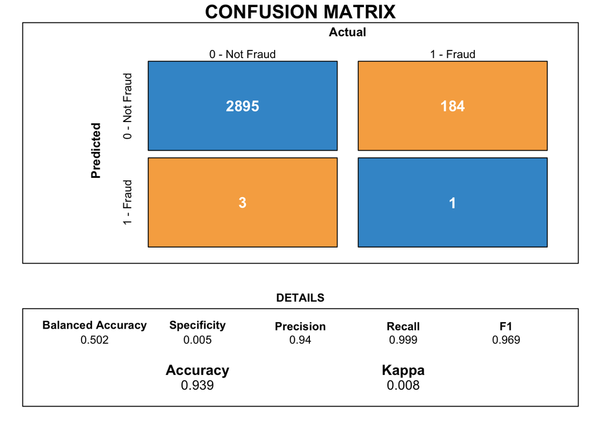

```r
# Draw Pretty Confusion Matrix
draw_confusion_matrix(caret::confusionMatrix(table(test_xp, test$FraudFound_P)))
```

# **Stepwise Regression**

```r
# Use Stepwise Regression to find the best parameters to keep. Since this takes a while to return, we have commented out the code that runs the stepAIC function and loaded the .RData object, see here:

#step_model <- stepAIC(base_log_reg, direction="both", steps = 10)
#save(step_model, file = "step_model_final_project_updated.RData")
load("step_model_final_project_updated.RData")

# Set the expression to be the best terms from the Step Model output
expr <- attributes(step_model$model)$terms

set.seed(777)

# Set weights
weights <- ifelse(train$FraudFound_P == 0, 0.1, 0.5)

# Create a new GLM model using the best terms
smaller_glm <- glm(expr, data=train, family=binomial(link=logit), weights = weights)

# Get predictions / fitted values from the train set
glm_train_results=smaller_glm$fitted.values

# Set 1 and 0
glm_train_results[glm_train_results>=0.5]=1
glm_train_results[glm_train_results<0.5]=0

# Train Results
caret::confusionMatrix(table(glm_train_results,train$FraudFound_P))
```

```
## Confusion Matrix and Statistics
##
##
## glm_train_results     0     1
##                 0 10821   518
##                 1   775   220
##
##                Accuracy : 0.8952
##                  95% CI : (0.8896, 0.9005)
##     No Information Rate : 0.9402
##     P-Value [Acc > NIR] : 1
##
##                   Kappa : 0.1988
##
##  Mcnemar's Test P-Value : 1.084e-12
##
##             Sensitivity : 0.9332
##             Specificity : 0.2981
##          Pos Pred Value : 0.9543
##          Neg Pred Value : 0.2211
##              Prevalence : 0.9402
##          Detection Rate : 0.8773
##    Detection Prevalence : 0.9193
##       Balanced Accuracy : 0.6156
##
##        'Positive' Class : 0
##
```

```r
MLmetrics::F1_Score(train$FraudFound_P, glm_train_results)
```

```
## [1] 0.9436233
```

```r
# Test Results
glm_test_results <- predict(smaller_glm, test, type="response")

# Set 1 and 0
glm_test_results[glm_test_results>=0.5]=1
glm_test_results[glm_test_results<0.5]=0

glm_test_results <- as.factor(glm_test_results)
log_step_pred <- glm_test_results

# Generate confusion matrix
caret::confusionMatrix(table(glm_test_results, test$FraudFound_P))
```

```
## Confusion Matrix and Statistics
##
##
## glm_test_results    0    1
##                0 2705  139
##                1  193   46
##
##                Accuracy : 0.8923
##                  95% CI : (0.8808, 0.903)
##     No Information Rate : 0.94
##     P-Value [Acc > NIR] : 1.000000
##
##                   Kappa : 0.1602
##
##  Mcnemar's Test P-Value : 0.003629
##
##             Sensitivity : 0.9334
##             Specificity : 0.2486
##          Pos Pred Value : 0.9511
##          Neg Pred Value : 0.1925
##              Prevalence : 0.9400
##          Detection Rate : 0.8774
##    Detection Prevalence : 0.9225
##       Balanced Accuracy : 0.5910
##
##        'Positive' Class : 0
##
```

```r
# Generate F1-score
print(paste("GLM Step Test F1-Score:", MLmetrics::F1_Score(glm_test_results, test$FraudFound_P)))
```

```
## [1] "GLM Step Test F1-Score: 0.942180424939046"
```

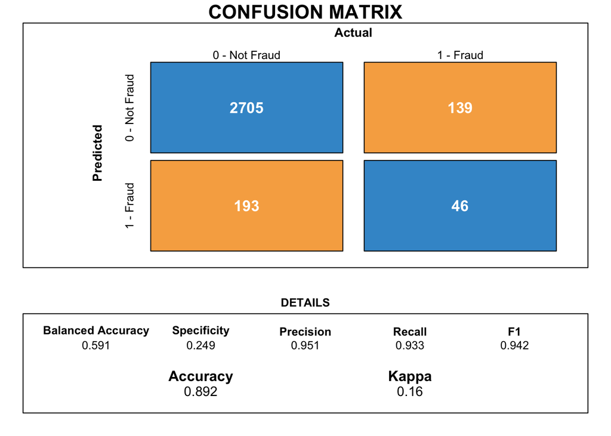

```r
# Draw Pretty Confusion Matrix
draw_confusion_matrix(caret::confusionMatrix(table(glm_test_results, test$FraudFound_P)))
```

# **Classification Tree**

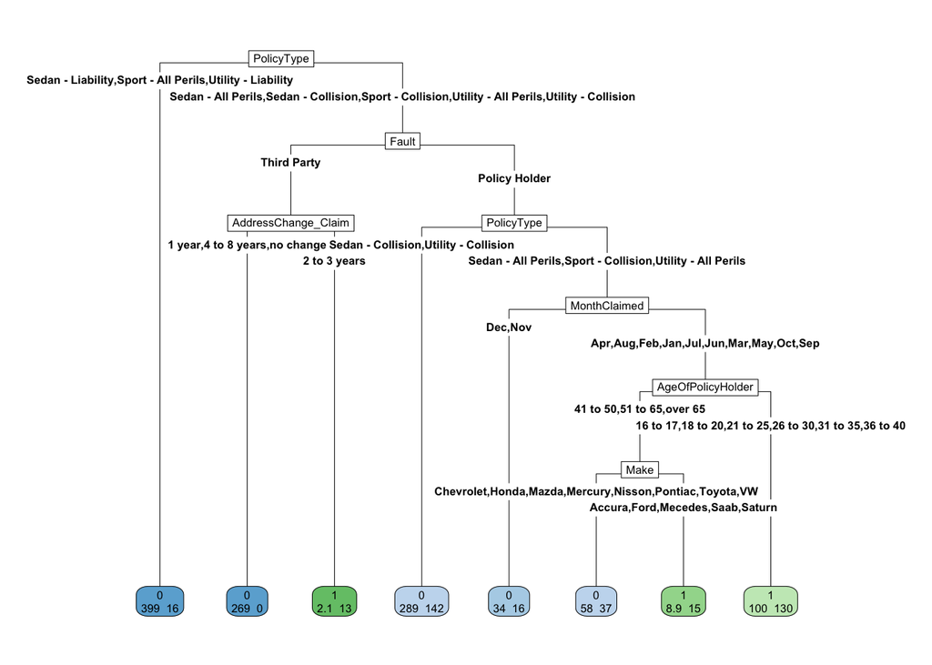

```r
# Create weights vector
weights <- ifelse(train$FraudFound_P == 0, 0.1, 0.5)

# Build classification tree model with weights
fraud_tree <- rpart(FraudFound_P ~ ., data = train, method = "class", weights = weights)

# Plot classification tree
rpart.plot(fraud_tree, type = 5, extra = 1)
```

```r
# Predict on training and testing datasets
train_preds <- predict(fraud_tree, train, type = "class")
test_preds <- predict(fraud_tree, test, type = "class")
tree_pred <- test_preds

# Evaluate performance on training and testing datasets
train_conf_mat <- table(train$FraudFound_P, train_preds)
test_conf_mat <- table(test$FraudFound_P, test_preds)

train_acc <- sum(diag(train_conf_mat)) / sum(train_conf_mat)
test_acc <- sum(diag(test_conf_mat)) / sum(test_conf_mat)

train_f1 <- MLmetrics::F1_Score(train$FraudFound_P, train_preds)
test_f1 <- MLmetrics::F1_Score(test$FraudFound_P, test_preds)

caret::confusionMatrix(table(test$FraudFound_P, test_preds))
```

```
## Confusion Matrix and Statistics
##
##    test_preds
##        0    1
##   0 2637  261
##   1  111   74
##
##                Accuracy : 0.8793
##                  95% CI : (0.8673, 0.8906)
##     No Information Rate : 0.8913
##     P-Value [Acc > NIR] : 0.984
##
##                   Kappa : 0.2247
##
##  Mcnemar's Test P-Value : 1.116e-14
##
##             Sensitivity : 0.9596
##             Specificity : 0.2209
##          Pos Pred Value : 0.9099
##          Neg Pred Value : 0.4000
##              Prevalence : 0.8913
##          Detection Rate : 0.8553
##    Detection Prevalence : 0.9400
##       Balanced Accuracy : 0.5903
##
##        'Positive' Class : 0
##
```

```r
print(paste("Classification Tree Training accuracy:", round(train_acc, 2)))
```

```
## [1] "Classification Tree Training accuracy: 0.88"
```

```r
print(paste("Classification Tree Testing accuracy:", round(test_acc, 2)))
```

```
## [1] "Classification Tree Testing accuracy: 0.88"
```

```r
print(paste("Classification Tree Training F1 score:", round(train_f1, 2)))
```

```
## [1] "Classification Tree Training F1 score: 0.93"
```

```r
print(paste("Classification Tree Testing F1 score:", round(test_f1, 2)))
```

```
## [1] "Classification Tree Testing F1 score: 0.93"
```

```r
print(paste("Classification Tree Testing Balanced Accuracy:", as.numeric(caret::confusionMatrix(table(test$FraudFound_P, test_preds))$byClass['Balanced Accuracy'][1])))
```

```
## [1] "Classification Tree Testing Balanced Accuracy: 0.590251254643812"
```

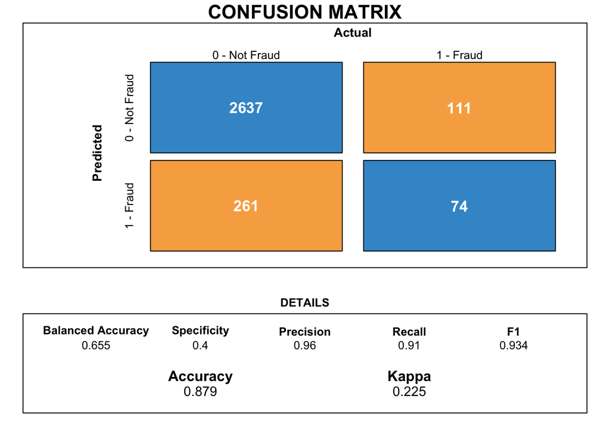

```r
# Draw Pretty Confusion Matrix
draw_confusion_matrix(caret::confusionMatrix(table(test_preds, test$FraudFound_P)))
```

### **Classification Tree Summary:** the classification tree performs more strongly than either GLM due to the high **balanced accuracy of 65%**. **The F1-score is also high at 93%.**

# **Support Vector Machine (SVM)**

```r
# Convert y variable to factor
train$FraudFound_P <- as.factor(train$FraudFound_P)

# The positive class is 6 times more important for us (analyzed different value results)
class_weights <- list("0" = 1, "1" = 6)

# Construct Radial SVM model with our class weights set above
svm.model <- svm(factor(FraudFound_P) ~ ., data = train, scale=TRUE,
                                            kernel = "radial",
                                            class.weights = class_weights)
# Make prediction on test set
svm_pred <- predict(svm.model, test)

# Generate confusion matrix
caret::confusionMatrix(table(test$FraudFound_P, svm_pred))
```

```
## Confusion Matrix and Statistics
##
##    svm_pred
##        0    1
##   0 2621  277
##   1  112   73
##
##                Accuracy : 0.8738
##                  95% CI : (0.8616, 0.8853)
##     No Information Rate : 0.8865
##     P-Value [Acc > NIR] : 0.9866
##
##                   Kappa : 0.2109
##
##  Mcnemar's Test P-Value : <2e-16
##
##             Sensitivity : 0.9590
##             Specificity : 0.2086
##          Pos Pred Value : 0.9044
##          Neg Pred Value : 0.3946
##              Prevalence : 0.8865
##          Detection Rate : 0.8501
##    Detection Prevalence : 0.9400
##       Balanced Accuracy : 0.5838
##
##        'Positive' Class : 0
##
```

```r
print(paste("SVM Test F1-score:", MLmetrics::F1_Score(test$FraudFound_P, svm_pred)))
```

```
## [1] "SVM Test F1-score: 0.930918131770556"
```

```r
print(paste("SVM Test Balanced Accuracy:", as.numeric(caret::confusionMatrix(table(svm_pred,test$FraudFound_P))$byClass['Balanced Accuracy'][1])))
```

```
## [1] "SVM Test Balanced Accuracy: 0.649505716897021"
```

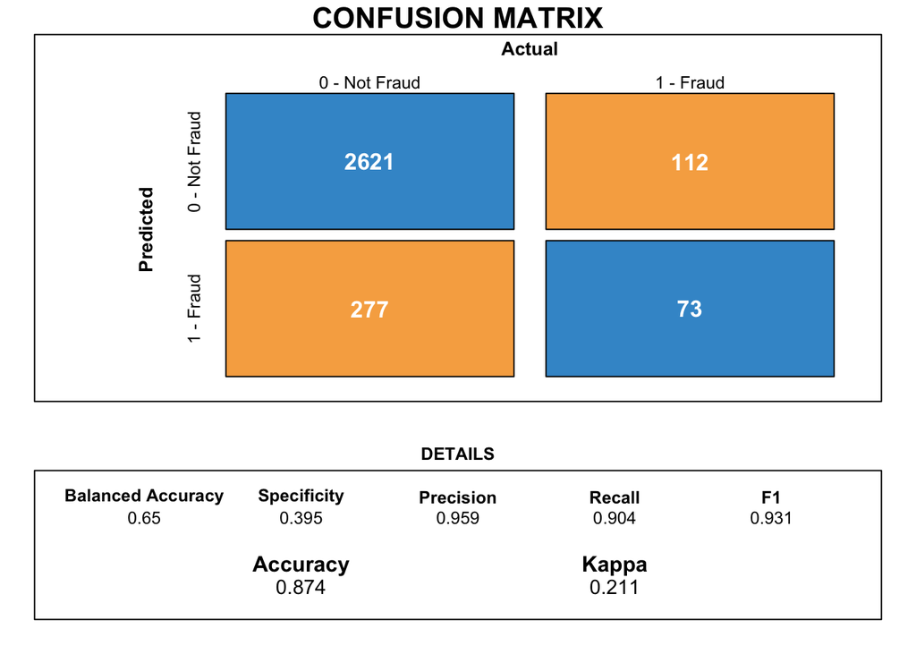

```r
# Draw Pretty Confusion Matrix
draw_confusion_matrix(caret::confusionMatrix(table(svm_pred, test$FraudFound_P)))
```

### **SVM Summary:** the **F1-score of 93% and Balanced Accuracy of 65%** of the SVM is consistent with the classification tree.

# **Naive Bayes**

```r
nb.model <- naivebayes::naive_bayes(FraudFound_P ~ ., data = train)
nb_pred <- predict(nb.model, test)

caret::confusionMatrix(table(test$FraudFound_P, nb_pred))
```

```
## Confusion Matrix and Statistics
##
##    nb_pred
##        0    1
##   0 2802   96
##   1  160   25
##
##                Accuracy : 0.917
##                  95% CI : (0.9067, 0.9265)
##     No Information Rate : 0.9608
##     P-Value [Acc > NIR] : 1
##
##                   Kappa : 0.1217
##
##  Mcnemar's Test P-Value : 8.233e-05
##
##             Sensitivity : 0.9460
##             Specificity : 0.2066
##          Pos Pred Value : 0.9669
##          Neg Pred Value : 0.1351
##              Prevalence : 0.9608
##          Detection Rate : 0.9089
##    Detection Prevalence : 0.9400
##       Balanced Accuracy : 0.5763
##
##        'Positive' Class : 0
##
```

```r
print(paste("Naive Best Test F1-Score:", MLmetrics::F1_Score(test$FraudFound_P, nb_pred)))
```

```
## [1] "Naive Best Test F1-Score: 0.956313993174062"
```

```r
print(paste("Naive Bayes Test Balanced Accuracy:", as.numeric(caret::confusionMatrix(table(nb_pred,test$FraudFound_P))$byClass['Balanced Accuracy'][1])))
```

```
## [1] "Naive Bayes Test Balanced Accuracy: 0.551004420569638"
```

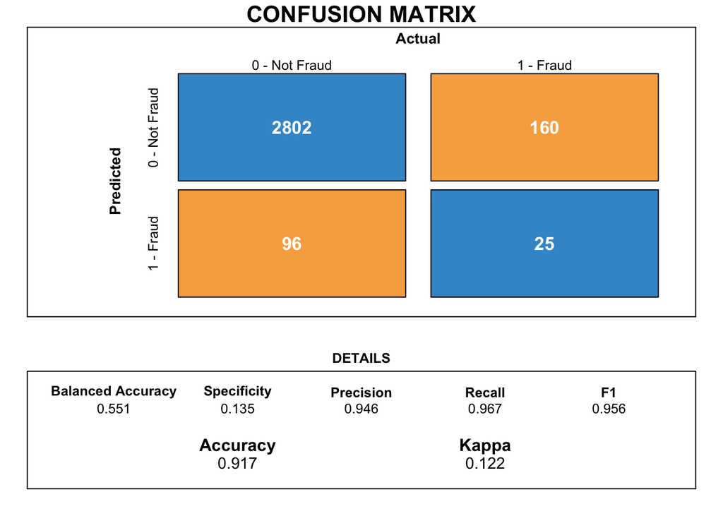

```r
# Draw Pretty Confusion Matrix
draw_confusion_matrix(caret::confusionMatrix(table(nb_pred, test$FraudFound_P)))
```

### **Naive Bayes Summary:** the Naive Bayes model returns an F1-score of 96% and Balanced Accuracy of 55%, indicating that the classification tree and SVM are the best performing models.

# **Ensemble Model**

### Below we have implemented an ensemble model that combines the output of all 5 models. For each prediction (row), if the row sum is greater than or equal to 3, the predicted value will be set to 1. This means a majority of the models predicted that particular record to be fraudulent. The resulting ensemble model should be more robust and accurate than the models individually.

```r
ensemble <- data.frame(cbind(logistic_all_vars = as.numeric(log_all_vars_pred),
                             logistic_post_stepwise = as.numeric(log_step_pred),
                             classification_tree = as.numeric(levels(tree_pred))[tree_pred],
                             naive_bayes = as.numeric(levels(nb_pred))[nb_pred],
                             svm = as.numeric(levels(svm_pred))[svm_pred]))

# Compute Majority
ensemble$final_prediction <- ifelse(rowSums(ensemble) >= 3, 1, 0)

# Summary
confusionMatrix(factor(test$FraudFound_P), factor(ensemble$final_prediction))
```

```
## Confusion Matrix and Statistics
##
##           Reference
## Prediction    0    1
##          0 2639  259
##          1  115   70
##
##                Accuracy : 0.8787
##                  95% CI : (0.8666, 0.89)
##     No Information Rate : 0.8933
##     P-Value [Acc > NIR] : 0.9955
##
##                   Kappa : 0.2118
##
##  Mcnemar's Test P-Value : 1.421e-13
##
##             Sensitivity : 0.9582
##             Specificity : 0.2128
##          Pos Pred Value : 0.9106
##          Neg Pred Value : 0.3784
##              Prevalence : 0.8933
##          Detection Rate : 0.8560
##    Detection Prevalence : 0.9400
##       Balanced Accuracy : 0.5855
##
##        'Positive' Class : 0
##
```

```r
print(paste("Ensemble Model Test Final F1-Score:", MLmetrics::F1_Score(test$FraudFound_P, ensemble$final_prediction)))
```

```
## [1] "Ensemble Model Test Final F1-Score: 0.93382873319179"
```

```r
print(paste("Ensemble Model Test Final Balanced Accuracy:", as.numeric(caret::confusionMatrix(table(ensemble$final_prediction,test$FraudFound_P))$byClass['Balanced Accuracy'][1])))
```

```
## [1] "Ensemble Model Test Final Balanced Accuracy: 0.644503198851025"
```

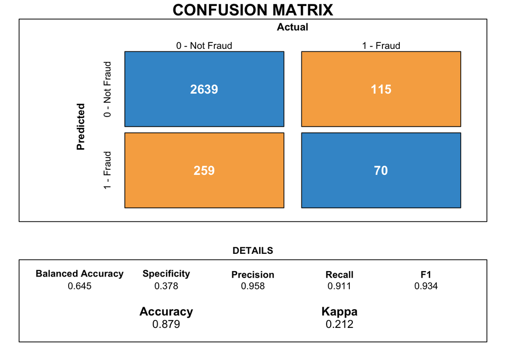

```r
# Draw Pretty Confusion Matrix
draw_confusion_matrix(caret::confusionMatrix(table(ensemble$final_prediction, test$FraudFound_P)))
```

### **Ensemble Final Summary:** The ensemble model returned strong predictive power with an **F1-score of 93% and Balanced Accuracy of 65%**. A balanced accuracy of 65% means that the model has correctly classified 65% of the samples on average across all classes. Though this number is not particularly high, helping an insurance company more easily catch a few cases of vehicle insurance fraud can make a difference. This number does not have to be high in order to have a positive effect for the company.

# **Unsupervised Analysis using t-SNE**

### t-SNE (t-Distributed Stochastic Neighbor Embedding) is a machine learning algorithm used for dimensionality reduction and data visualization. It is a nonlinear method for reducing the high-dimensional data into a lower-dimensional space, typically 2D or 3D, while preserving the local and global structure of the data.

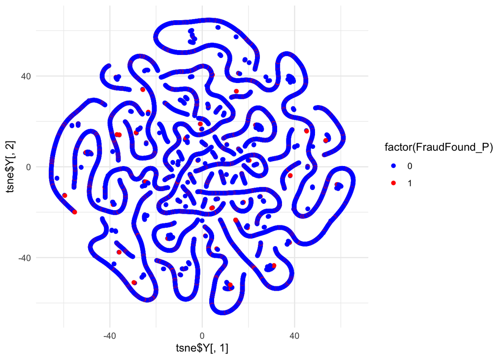

```r
numeric_data <- select_if(df, is.numeric)

# Run t-SNE
set.seed(123)
tsne <- Rtsne(numeric_data, check_duplicates = FALSE)

# Visualize t-SNE plot
tsne_df <- data.frame(tsne$Y, FraudFound_P = df$FraudFound_P)
ggplot(tsne_df, aes(x = tsne$Y[, 1], y = tsne$Y[, 2], color = factor(FraudFound_P))) +
  geom_point() +
  scale_color_manual(values = c("blue", "red")) +
  theme_minimal()
```